# DES_part1_03735990

# Programming Assignment 1: Implementing the Discrete Event Simulator

## Task 1.5: Verification

```python
# Task 1.5
%run "part1_tests"
```

```
......
----------------------------------------------------------------------
Ran 6 tests in 0.014s

OK
```

## Task 1.6: Analysis and General Questions

### 1.6.1: Confidence

The test is ran 5 times and was successful everytime with the simulation time ranging from 0.010 seconds to 0.030 seconds. Successful running of the test ensures statistical confidence.

### 1.6.2: Event Chain Structure

In the EventChain, Heap data structure helps implement an array which sorts the events according to timestamp and priority. When the service of one event is completed, it pops it out first and then adds the next event for processing.

### 1.6.3: Update Event Chain

If we insert all events at the beginning of simulation, we will lose the effects caused by the dynamic response of the system. The code will be inefficient and less readable if we insert all the custom arrivals at the beginning of the code.

Since each packet consumes a random amount of time to be processed, it will be harder to insert events at the beginning of the code for service completion.

## Task 1.7: Simulation Study I

### 1.7.1: Queue Length Determination I

The idea is to find out the queue length where after 100 seconds the number of dropped packets is less than 10 for at least 80% of 1000 simulation runs. Hence the code runs a 1000 simulation runs for a fixed buffer length ( I started with 4), and counts the number of runs where the number of dropped packets was less than 10. This number divided by 1000 ( Number of runs) gives the the success percentage. If this Success percentage is less than 80, then we need to increase our buffer size, hence the same process is run after incrementing the buffer size by one. At a point, we will reach the have the Success Percentage greater than 80 and ideally this should be our desired optimum buffer size. However this Succes Percentage may also vary and will have a certain uncertainity, hence the code then slips in the ReTest part where it checks the 1000 simulation runs 10 times and checks if the Success Ratio is greater than 80 percent for all the 10 times. If the the Success ratio is less than 10 for even 1 of those 10 Tests then we need to increase the buffer size by one once again and test the Success ratio once again as. Hence, we can be assured that variation in the Succes Ratio does not affect our result.

```python
#Task 1_7_1
import part1_simstudy
print(part1_simstudy.task_1_7_1())
```

```
Buffer Size: 4    Success Rate: 0.577
Buffer Size: 5    Success Rate: 0.689
Buffer Size: 6    Success Rate: 0.764
Buffer Size: 7    Success Rate: 0.825
Test Succesfull, starting retest routine
Succesfull ReTest Number 1 had Success Rate of: 0.838
Succesfull ReTest Number 2 had Success Rate of: 0.827
Succesfull ReTest Number 3 had Success Rate of: 0.818
Succesfull ReTest Number 4 had Success Rate of: 0.836
Succesfull ReTest Number 5 had Success Rate of: 0.8
Succesfull ReTest Number 6 had Success Rate of: 0.831
Succesfull ReTest Number 7 had Success Rate of: 0.82
Succesfull ReTest Number 8 had Success Rate of: 0.836
Succesfull ReTest Number 9 had Success Rate of: 0.83
Succesfull ReTest Number 10 had Success Rate of: 0.824
The Queue length required such that after 100.0 seconds, less than 10 packets are dropped in 80% of the cases is 7
7
```

### 1.7.2: Queue Length Determination II

For this task, we are changing some parameters of SimParam before calling the function.

```python
#Task 1_7_2
import part1_simstudy
print(part1_simstudy.task_1_7_2())
```

```
Buffer Size: 4    Success Rate: 0.42
Buffer Size: 5    Success Rate: 0.84
Test Succesfull, starting retest routine
ReTest number 1 Failed because the Success Rate was0.79
Buffer Size: 6    Success Rate: 0.87
Test Succesfull, starting retest routine
Succesfull ReTest Number 1 had Success Rate of: 0.94
Succesfull ReTest Number 2 had Success Rate of: 0.9
Succesfull ReTest Number 3 had Success Rate of: 0.88
Succesfull ReTest Number 4 had Success Rate of: 0.9
Succesfull ReTest Number 5 had Success Rate of: 0.84
Succesfull ReTest Number 6 had Success Rate of: 0.88
Succesfull ReTest Number 7 had Success Rate of: 0.87
Succesfull ReTest Number 8 had Success Rate of: 0.94
Succesfull ReTest Number 9 had Success Rate of: 0.86
Succesfull ReTest Number 10 had Success Rate of: 0.86
The Queue length required such that after 1000.0 seconds, less than 100 packets are dropped in 80% of the cases is 6
6
```

Here, we want to have less than 100 dropped packets in 80% of the cases for 1000 seconds. The required queue length in this case is 6. This time required buffer size to have same succes is decreased. This is due to the fact that the transient response of the system causes a large variation in the blocking probability of a packet.

### 1.7.3: Comaparision of Results

```
Standard Deviation for simulation time = 100 sec is 0.022329318245338486
Standard Deviation for simulation time = 500 sec is 0.010295106209237093
Standard Deviation for simulation time = 1000 sec is 0.007481514351143135
Standard Deviation for simulation time = 1500 sec is 0.006327389011727015
Standard Deviation for simulation time = 2000 sec is 0.00550400584734898
```

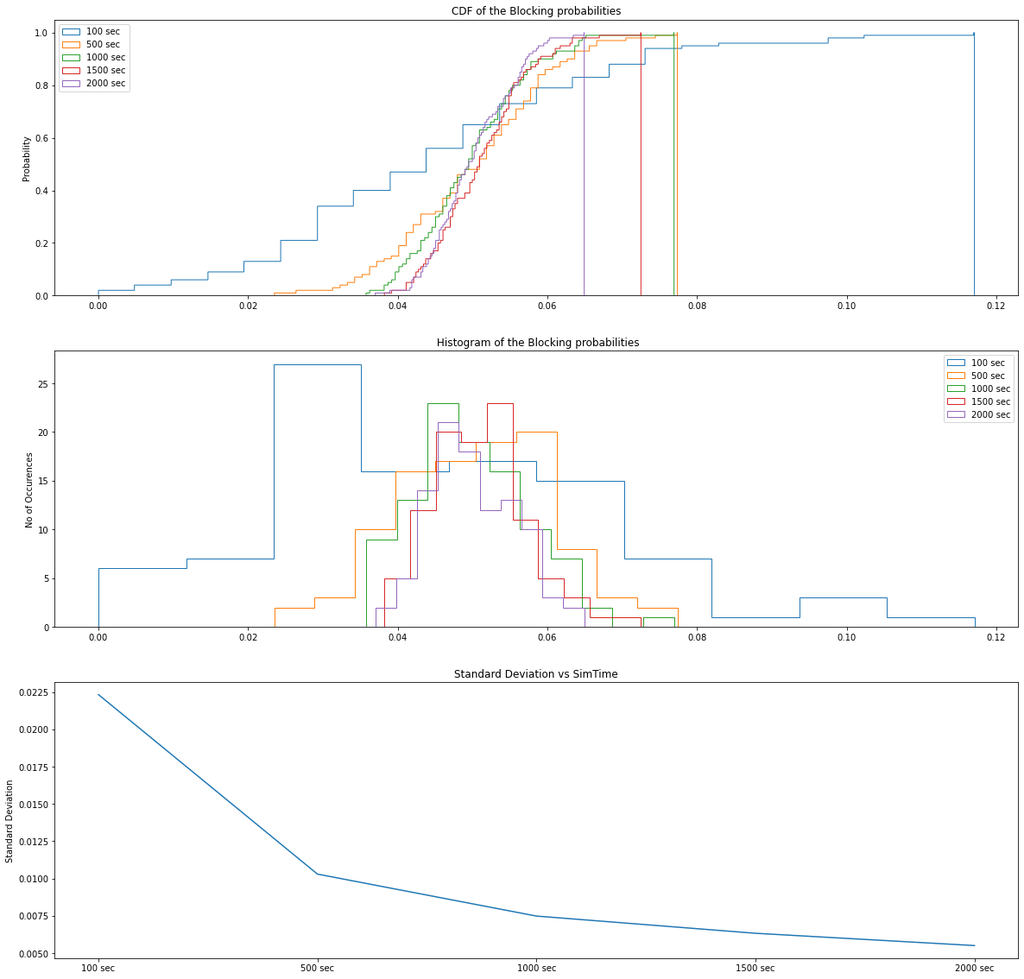

```python
#Task 1.7.3
import part1_simstudy
part1_simstudy.task_1_7_3()
```

As can be seen from the two above figures, the simulation time greatly affects the accuracy with which we can predict the blocking probabilities. The above tests were done in order to plot the distribution of blocking probabilities for a buffer size of 4 and simulation time of 100,500,1000,1500 and 2000 seconds. We observe that as the simulation time increases, the variance of the blocking probability reduces and they start converging to their mean. The distribution of the blocking probabilities is more or less gaussian and a sharper increase in the CDF denotes a data set with less variance. Hence in Task 1.7.1 we get a higher buffer size as there are some simulation runs where the blocking probability is much higher than the mean. In task 1.7.2 we get a lower value as the blocking probabilities have less variance and the chance that they fall outside our specified value is less, and a smaller buffer size can be allowed. From these observations and comparing results from the tests in 1.7.1 and 1.7.2, we understand that 100 seconds is too less a time for simulation if we wish to determine steady state parameters such as buffer size for a specified steady state success probability i.e. We need a larger simulation time in order to reach the correct value of a steady state buffer size for the given succes ratio (80%). The plot of the decay in standard deviation of the blocking probabilities can give us a rough idea on how much our simulation time can be. We see that there is a large difference in the standard deviation of the blocking probabilities when we increase the simulation time from 500 seconds to 1000 seconds. However this gain is not very significant when we increase the simulation time from 1500 to 2000 seconds. However the computational effort when increasing the simulation time. Hence we can limit the simulation time to a reasonable value above 1000 seconds.